# La Guerra de Florence Nightingale

[interactive chart not shown]

[figure not shown]

El gran drama de la **Guerra de Crimea (1853-1856)** no fueron ni las batallas, ni los bombardeos, ni los ataques. Fueron enfermedades zimóticas como el cólera, el tifus, la fiebre tifoidea o la disentería las que causaron más bajas en ambos bandos, sobre todo durante el invierno de 1854 y 1855.

**Florence Nightingale**, enfermera inglesa con grandes aptitudes para las matemáticas, libró una dura batalla contra las enfermedades infecciosas, fruto de las pésimas condiciones sanitarias de los soldados británicos. Y es que, según los datos de Florence y que se visualizan a continuación, estas enfermedades causaron el **80%** del total de muertes durante el transcurso de la guerra.

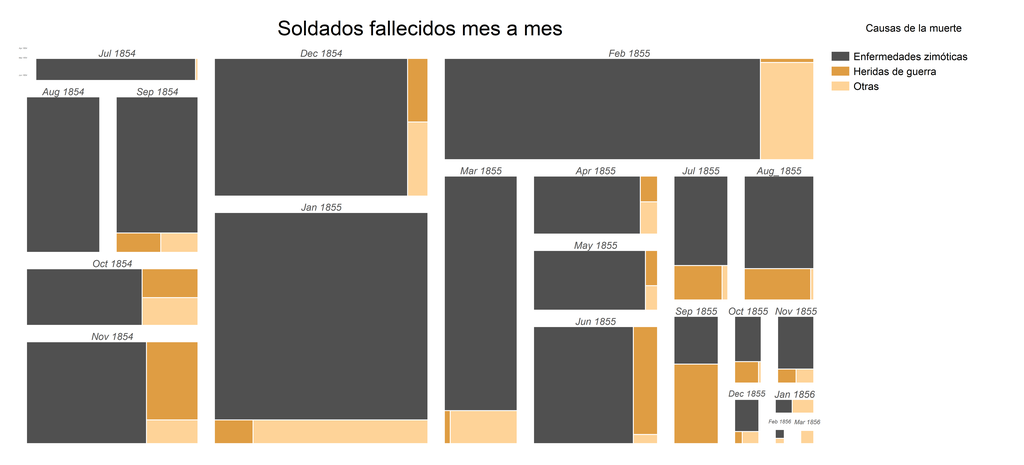

El primer invierno de Florence fue devastador. Solo en enero de 1855 murieron 3.168 soldados británicos, 2.761 de ellos por enfermedades infecciosas.

La saturación médica y la evidente carencia de higiene en el hospital abrumaron a Florence, quien empezó una campaña para conseguir mejorar las condiciones sanitarias. En marzo de 1855, el gobierno británico destinó una **comisión sanitaria a Scutari**: Florence ordenó la limpieza inmediata de vertederos contaminantes, mejoró la ventilación del hospital y realizó pequeños cambios de gran impacto como la renovación de toallas y ropa de los hospitalizados.

[figure not shown]

A partir de esas medidas, el índice de mortalidad bajó rápidamente. En septiembre de 1855, tan solo cuatro de cada diez soldados morían por una enfermedad infecciosa. Las reformas sanitarias suavizaron la curva de muertes acumuladas y evitaron otro invierno negro. La victoria de Florence contra las enfermedades zimóticas coincidió con la victoria de los aliados (Reino Unido, Francia, Turquía y Cerdeña) contra el Imperio ruso y Grecia.

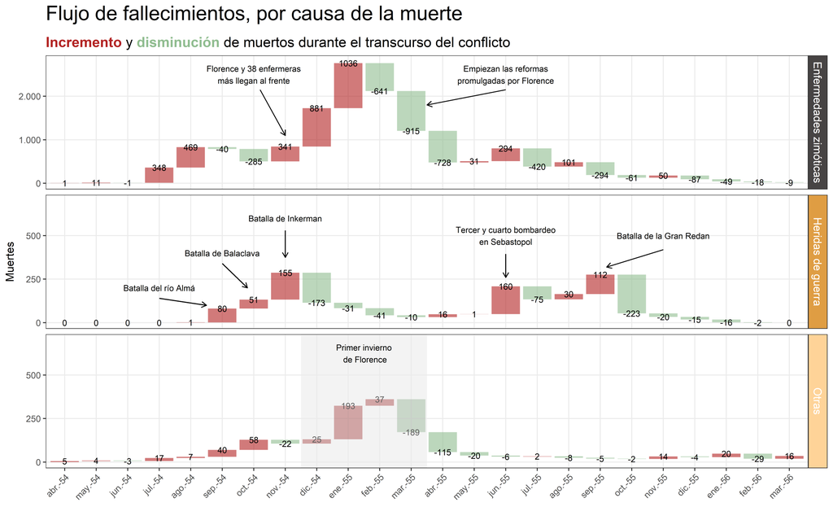